# H06_daily: H01-aligned diagnostic amendment

No-refit visual review and H06-D-G2A author gate

Published

August 12, 2026

**ImportantAnswer in brief**

Applying the author-approved H01 architecture changes the interpretation of the stored H06_daily diagnostics without changing a model or inferential quantity. Direct visual inspection found ordinary, reportable residual limitations in every reviewed cell, but no gross residual failure. AR, deletion influence, exact-period, and response-family checks are now nonblocking sidecars.

The review also exposed a separate hard construct failure: all five gap-timing-unaware clock metrics entered H06_daily already in clock hours and were divided by 60 a second time. Consequently, **90 stored gap timing cells are not acceptable and all six gap BH families are blocked**. The primary dataset is not affected by this unit defect. No frozen estimate, interval, raw p-value, rank, BH value, or BH decision was changed.

# Scope and controlling rule

This amendment implements `H06-D-014 / CHG-127`. It supersedes only the diagnostic-status and dependent claim-eligibility interpretation in the frozen H06-D-G2 report. It does not overwrite that report and does not alter the hourly main H06 analysis, which remains the selected primary analysis. H06_daily remains complementary, preregistration-oriented participant-day evidence.

The H01-aligned rule has three outcomes:

- **Not acceptable** (`FAIL_MAJOR_GATE`) only for a base fit or required result failure, nonconvergence, Hessian/singularity/rank/covariance non-estimability, missing clock support, invalid observed support, a genuine construct failure, or a visually confirmed gross residual failure.
- **Acceptable with limitations** (`WARN_REVIEW`) when no hard gate fails but visual review finds a non-gross residual limitation, or a base prediction, audit, or fit warning remains.
- **Acceptable** (`PASS`) when neither condition applies.

AR evidence, participant/site deletion results, exact-period checks, and Student-t/Tweedie/family sensitivities remain mandatory and visible, but they do not determine the overall class. They would become hard failures only if they exposed a genuine construct or observed-support problem.

# Reproduced pre-visual mapping

Before replacing numeric residual thresholds with visual judgment, the frozen distribution-gate fields reproduce the expected implementation cross-check exactly.

Table 1: Frozen pre-visual H01 mapping reproduced before manual residual review.

| Class | Cells |
| --- | --- |
| All production cells |  |
| PASS | 311 |
| WARN_REVIEW | 157 |
| FAIL_MAJOR_GATE | 0 |
| Primary near-eye, all-available cells |  |
| PASS | 26 |
| WARN_REVIEW | 13 |
| FAIL_MAJOR_GATE | 0 |

These 311/157/0 and 26/13/0 counts are not the final visual result. No numeric normality, heteroscedasticity, residual-correlation, or outlier threshold was allowed to set a visual verdict.

# Complete visual residual review

All 468 non-L10 production cells and the three stored shifted-log L10 pilot cells were inspected in 37 indexed atlases. Each cell has a readable plot, a paired source-data CSV, hashes for both files, reviewer/date fields, reason codes, and a plain-language explanation.

- Gaussian mixed-model and participant-cluster HC3 cells were judged from residual-versus-fitted, Q-Q, and scale-location displays.
- Tweedie cells were judged from Pearson-residual-versus-fitted, observed zero-mass, and observed-versus-fitted support displays. Pearson residuals were not required to be normal.

The plots consistently showed visible centering, scale, tail, or zero-support patterns that warrant disclosure. None was visually gross enough to invalidate a base fit. Thus, all 471 visual verdicts are `REVIEW_LIMITATION`; none is `FAIL_GROSS`.

Table 2: Manual visual verdicts by frozen model route.

| Route | Family | Verdict | Cells |
| --- | --- | --- | --- |
| Non-L10 production |  |  |  |
| Mixed model | Gaussian | REVIEW_LIMITATION | 216 |
| Mixed model | Tweedie log | REVIEW_LIMITATION | 108 |
| Participant-cluster HC3 | Gaussian | REVIEW_LIMITATION | 144 |
| Shifted-log L10 pilot |  |  |  |
| shifted_log_gaussian_mixed_pilot | Gaussian | REVIEW_LIMITATION | 3 |

Representative frozen-cell displays are shown below. The full audit is in `H06_daily_h01_visual_residual_atlas_index.csv`; the images are diagnostic evidence, not new model output.

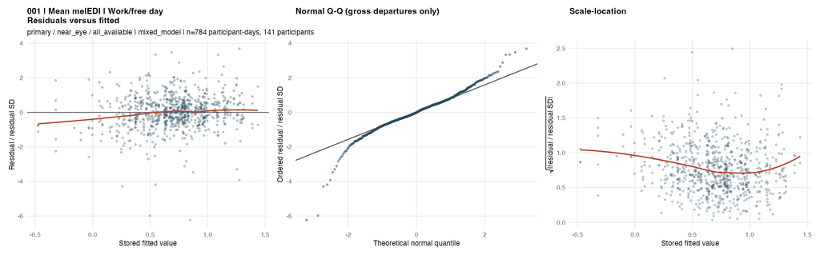

Gaussian example: residuals versus fitted, Q-Q, and scale-location panels for a frozen mean-melEDI model. Visible curvature and tail departure were judged a limitation, not a gross failure.

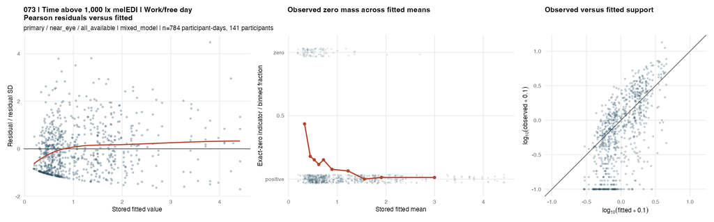

Tweedie example: Pearson residuals, observed zero mass, and observed-versus-fitted support for a frozen time-above-1,000-lx model. Visible zero/support structure was retained as a limitation.

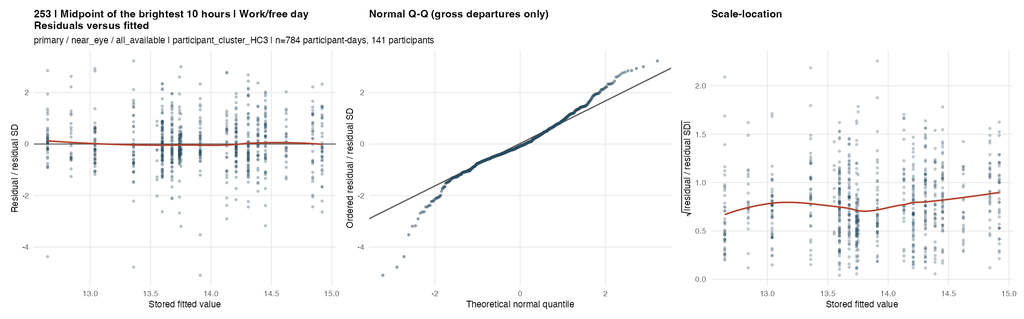

Participant-cluster HC3 timing example: residuals versus fitted, Q-Q, and scale-location panels for a frozen M10-midpoint model. The robust route remains accepted, with the visible residual limitation disclosed.

# Hard timing-unit finding

The hard-gate replay initially found that mean timing lacked the clock-support field used by the four repaired HC3 timing outcomes. The ensuing R 4.6.1 unit audit established that this was part of a broader task-local adapter defect:

1. Current primary timing fields are clock minutes.
2. The pinned gap-timing-unaware artifact stores the five timing metrics in clock hours. Its independently audited H01 adapter converts those values back to clock minutes before applying a minute-to-hour model transform.
3. The H06_daily adapter applied its minute-to-hour transform directly to the already-hour-valued gap source.
4. For every affected frozen cell, the stored model response is exactly the gap source divided by 60.

This is a unit/construct failure, not an AR or residual-distribution issue. It affects five metrics, two placements, three predictors, and three sample roles: 90 cells in total.

Table 3: Frozen gap timing cells affected by the hour-to-hour/60 double conversion.

| Slot | Metric | Gap source range (clock h) | Stored response range | Affected cells | Gate |
| --- | --- | --- | --- | --- | --- |
| Chest |  |  |  |  |  |
| 9 | m10_midpoint | 4.983 to 18.983 | 0.0831 to 0.3164 | 9 | FAIL_CONSTRUCT_UNIT_DOUBLE_CONVERSION |
| 10 | l10_midpoint | -11.900 to 8.700 | -0.1983 to 0.1450 | 9 | FAIL_CONSTRUCT_UNIT_DOUBLE_CONVERSION |
| 11 | mean_timing_above_250 | 2.645 to 20.672 | 0.0441 to 0.3445 | 9 | FAIL_CONSTRUCT_UNIT_DOUBLE_CONVERSION |
| 12 | first_timing_above_250 | 0.000 to 20.650 | 0.0000 to 0.3442 | 9 | FAIL_CONSTRUCT_UNIT_DOUBLE_CONVERSION |
| 13 | last_timing_above_250 | 7.750 to 23.917 | 0.1292 to 0.3986 | 9 | FAIL_CONSTRUCT_UNIT_DOUBLE_CONVERSION |
| Near eye |  |  |  |  |  |
| 9 | m10_midpoint | 4.983 to 18.983 | 0.0831 to 0.3164 | 9 | FAIL_CONSTRUCT_UNIT_DOUBLE_CONVERSION |
| 10 | l10_midpoint | -11.883 to 11.983 | -0.1981 to 0.1997 | 9 | FAIL_CONSTRUCT_UNIT_DOUBLE_CONVERSION |
| 11 | mean_timing_above_250 | 8.147 to 19.839 | 0.1358 to 0.3306 | 9 | FAIL_CONSTRUCT_UNIT_DOUBLE_CONVERSION |
| 12 | first_timing_above_250 | 0.000 to 18.533 | 0.0000 to 0.3089 | 9 | FAIL_CONSTRUCT_UNIT_DOUBLE_CONVERSION |
| 13 | last_timing_above_250 | 8.733 to 23.983 | 0.1456 to 0.3997 | 9 | FAIL_CONSTRUCT_UNIT_DOUBLE_CONVERSION |

Because the five invalid raw tests occupy slots in every gap association and heterogeneity vector, all six gap-timing-unaware 15-slot BH families are scientifically blocked. Their stored raw and adjusted values remain preserved for provenance but must not be interpreted. Repair requires a separately authorized rebuild of only the task-owned gap timing frames/models and their dependent BH fields.

# Final H01-aligned classes

Table 4: Final post-visual H01-aligned classification of the 468 non-L10 production cells.

| H01 class | Reader label | Cells |
| --- | --- | --- |
| PASS | Acceptable | 0 |
| WARN_REVIEW | Acceptable with limitations | 378 |
| FAIL_MAJOR_GATE | Not acceptable | 90 |

The 90 failures are exactly the gap timing unit failures. The other 378 cells have acceptable base fits and observed support but retain explicit visual limitations. `PASS = 0` does not mean those 378 results are rejected; it means the visual departures were material enough that none should be described as limitation-free.

# Multiplicity and claim eligibility

No raw p-value, BH-adjusted p-value, family rank, or raw/adjusted decision was changed. The amendment changes only whether an existing FDR-supported result is eligible for a carefully qualified observational claim.

Table 5: FDR support and H01-aligned claim eligibility; frozen p/FDR fields are unchanged.

| Test | Named non-L10 slots | FDR supported | Family construct valid | Claim eligible | Newly eligible under H01 |
| --- | --- | --- | --- | --- | --- |
| Gap-timing-unaware |  |  |  |  |  |
| Association | 39 | 29 | No | 0 | 0 |
| Site heterogeneity | 39 | 11 | No | 0 | 0 |
| Primary |  |  |  |  |  |
| Association | 39 | 28 | Yes | 28 | 23 |
| Site heterogeneity | 39 | 10 | Yes | 10 | 9 |

For the primary dataset, 28 association and 10 heterogeneity tests have FDR support and no hard diagnostic gate; 32 of these become claim-eligible under the H01 rule after AR/influence checks cease to be automatic failures. Every such claim still requires the recorded limitations. In particular, timing predictor-by-site interactions remain sensitivity-dependent and cannot support an unqualified site-heterogeneity statement.

For the gap-timing-unaware dataset, no FDR claim is eligible until the six families are rebuilt after the timing-unit repair. This family-level block also applies to non-timing slots because their q-values depend on the five invalid timing raw p-values. The L10 named-NA slot remains missing. MDER models and raw tests remain frozen; gap MDER’s existing BH derivative is not interpretable while its family is blocked.

# Required sidecars remain visible

The original 468-row AR, influence, exact-period, and response-family fields were copied row-for-row into the derived classification table and verified object-identical before serialization.

Table 6: Row-linked diagnostic sidecars retained without contributing to the overall H01 class.

| Sidecar | Fields | Rows | Exact identity | Sets overall class |
| --- | --- | --- | --- | --- |
| AR / temporal dependence | 34 | 468 | Yes | No |
| Participant/site deletion influence | 10 | 468 | Yes | No |
| Exact-period sensitivity | 5 | 468 | Yes | No |
| Response-family sensitivity | 23 | 468 | Yes | No |

The AR summaries therefore remain reportable: unresolved/nonconverged AR counterparts, post-AR residual dependence, rho values, and effect shifts are limitations, not automatic failures. Participant/site deletion instability, exact-period sensitivity, and Student-t/Tweedie shifts remain equally visible and must accompany any affected scientific statement.

# Shifted-log L10 pilot

The three already fitted shifted-log L10 pilot cells pass their base numerical hard gates. Visual review found right-tail, centering, and nonconstant-variance limitations; AR-only failure is now a nonblocking sidecar. Each pilot cell is therefore **acceptable with limitations** as a diagnostic classification.

Table 7: No-refit H01-aligned reassessment of the stored shifted-log L10 pilot.

| Predictor | Visual verdict | H01 class | Reader label | AR sidecar | Pilot p accepted |
| --- | --- | --- | --- | --- | --- |
| Work/free day | REVIEW_LIMITATION | WARN_REVIEW | Acceptable with limitations | NOT_ACCEPTABLE_POST_AR_RESIDUAL_DEPENDENCE | No |
| Activity status | REVIEW_LIMITATION | WARN_REVIEW | Acceptable with limitations | NOT_ACCEPTABLE_POST_AR_RESIDUAL_DEPENDENCE | No |
| Previous-night sleep duration | REVIEW_LIMITATION | WARN_REVIEW | Acceptable with limitations | NOT_ACCEPTABLE_POST_AR_RESIDUAL_DEPENDENCE | No |

This does **not** authorize the full shifted-log L10 batch, populate slot 3, accept a pilot p-value, or replace the historical two-part result. The two-part route remains not acceptable/non-estimable because component separation is a hard estimability failure; raw and adjusted p-values remain missing.

# Scientific interpretation

The amendment separates three questions that the previous H06_daily gate had combined:

1. **Is the stored base analysis estimable and on the intended construct?** Yes for 378 non-L10 cells; no for the 90 double-converted gap timing cells.
2. **Does a complete primary BH family support an association or heterogeneity test?** This is unchanged numerically.
3. **How robust is the result to temporal, influence, period, or family alternatives?** Those findings remain mandatory qualifications but are not automatic H01 failures.

An eligible result is not necessarily strong, robust, causal, or equivalent to the hourly H06 result. All statements remain observational associations with recorded day-level contexts. H06_daily and the hourly main H06 address different estimands and are not numerically interchangeable.

# Reproducibility and protected identities

- R version: 4.6.1.
- Visual evidence: 471 cell plots with paired source CSVs and 37 indexed atlases.
- Protected frozen identities verified before and after: 1,011 records, all unchanged.
- H06-D-G2 scientific models, estimates, intervals, raw p-values, FDR values, deletion outputs, and historical reports were not rewritten.
- The global change log changed through accepted unrelated coordinator work (CHG-128 and CHG-129) after H06-D-014 was sealed. This amendment pins the stable H06-D-014 decision and decision register and does not consume those unrelated rows.

# H06-D-G2A author stop gate

Recommended disposition:

1. Accept the H01 three-class architecture and the complete visual review: 378 `WARN_REVIEW`, 90 `FAIL_MAJOR_GATE`, and no gross residual failures.
2. Accept the hard construct finding and block all 90 stored gap timing cells plus all six gap BH families from interpretation.
3. Retain every AR, influence, exact-period, and response-family finding as a mandatory nonblocking sidecar.
4. Accept the 38 FDR-supported primary tests as diagnostically claim-eligible only with their row-specific limitations; retain the sensitivity-dependent qualification for timing site interactions.
5. Retain the shifted-log L10 pilot as diagnostically acceptable with limitations only; do not authorize its raw p-values, BH slot, or full production batch here.
6. If the gap sensitivity is to be retained, authorize a separate targeted task-owned repair that converts gap clock hours to the registered timing scale exactly once, rebuilds only the 90 affected frames/models and their six dependent BH families, and then repeats the bounded visual/hard-gate review. No such repair was performed here.

**Stop: H06-D-G2A awaits explicit author review. Stage 3 and Stage 4 remain blocked.**